# GDP per Capita and Life Expectancy in 2020

## Data overview

The analysis uses GDP per capita (`gdp_pcap.csv`) and life expectancy at birth (`lex.csv`). Both datasets list countries by ISO code (`geo`) and country name (`name`), with one column per year.

| Code | Country | GDP per capita (2020) |
| --- | --- | --- |
| afg | Afghanistan | 2769.686 |
| ago | Angola | 7556.968 |
| alb | Albania | 14662.796 |
| and | Andorra | 55488.490 |
| are | UAE | 65784.677 |
| arg | Argentina | 23877.093 |
| arm | Armenia | 15052.936 |
| atg | Antigua and Barbuda | 23930.672 |

Sample of GDP per capita in 2020

| Code | Country | Life expectancy (2020) |
| --- | --- | --- |
| afg | Afghanistan | 64.6 |
| ago | Angola | 62.8 |
| alb | Albania | 77.4 |
| and | Andorra | 82.7 |
| are | UAE | 79.5 |
| arg | Argentina | 76.4 |
| arm | Armenia | 70.7 |
| atg | Antigua and Barbuda | 77.3 |

Sample of life expectancy in 2020

## 2020 subsets

In 193 countries report GDP per capita for 2020; 194 report life expectancy. After merging on country code, 193 countries have both indicators.

## World map: GDP per capita (2020)

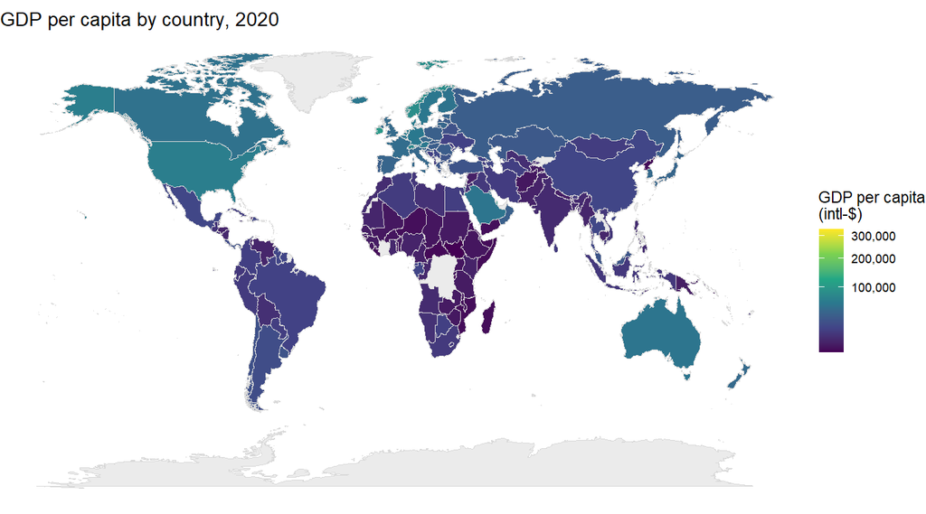

## World map: life expectancy (2020)

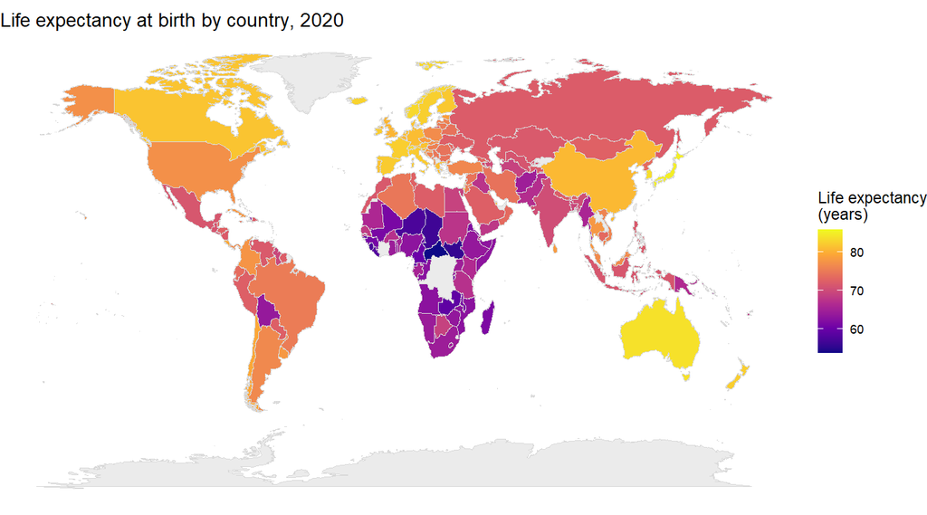

## Relationship between GDP per capita and life expectancy

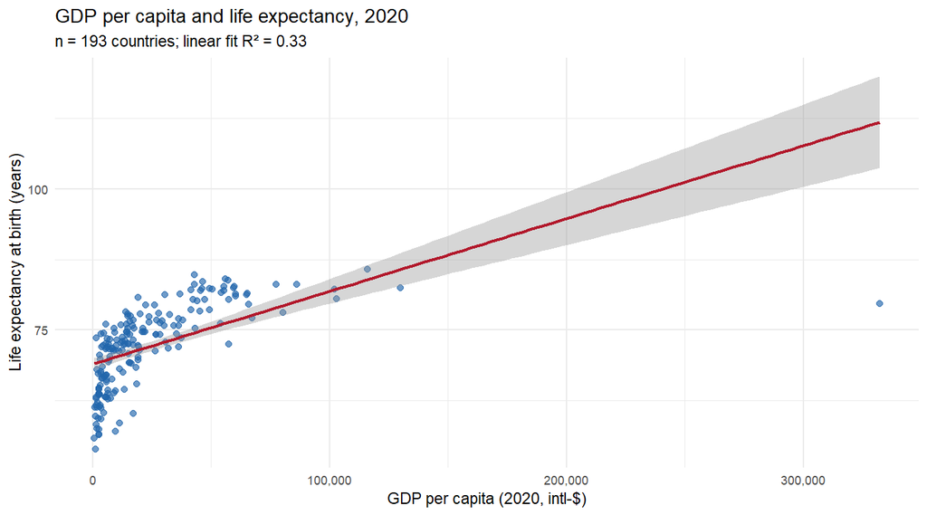

## Interpretation

The relationship is not perfectly linear. At low income levels, gains in GDP are often accompanied by relatively large improvements in longevity (basic health, nutrition, and sanitation). Among already high-income countries, additional GDP growth is associated with smaller marginal gains in life expectancy, producing a pattern of diminishing returns.

The world maps highlight similar geographic patterns for both indicators: much of sub-Saharan Africa and parts of South Asia show lower GDP and lower life expectancy, whereas North America, Western Europe, East Asia, and Oceania rank higher on both measures. Discrepancies remain—some middle-income countries achieve life expectancy comparable to richer nations through strong public health systems, while a few high-income outliers sit below the trend because of inequality, diet, or other non-economic factors.